# Exploratory Data Analysis

Owais

2025-04-04

# Introduction

This exploratory data analysis (EDA) examines the diamonds dataset from ggplot2 to understand relationships between diamond characteristics and their prices. EDA follows a structured approach of:

> Question formulation

> Data cleaning and transformation

> Visualization and modeling

> Insight generation

## Key Questions

> What type of variation occurs within individual variables?

> What relationships exist between different variables?

> How do diamond characteristics influence pricing?

## Data Overview

> Price (continuous): US dollars ($326-$18,823)

> Carat (continuous): Diamond weight (0.2-5.01)

> Cut (ordinal): Quality (Fair, Good, Very Good, Premium, Ideal)

> Color (ordinal): J (worst) to D (best)

> Clarity (ordinal): I1 (worst) to IF (best)

## Data Processing

### Variation Analysis

#### First, we will look at **categorical** variables.

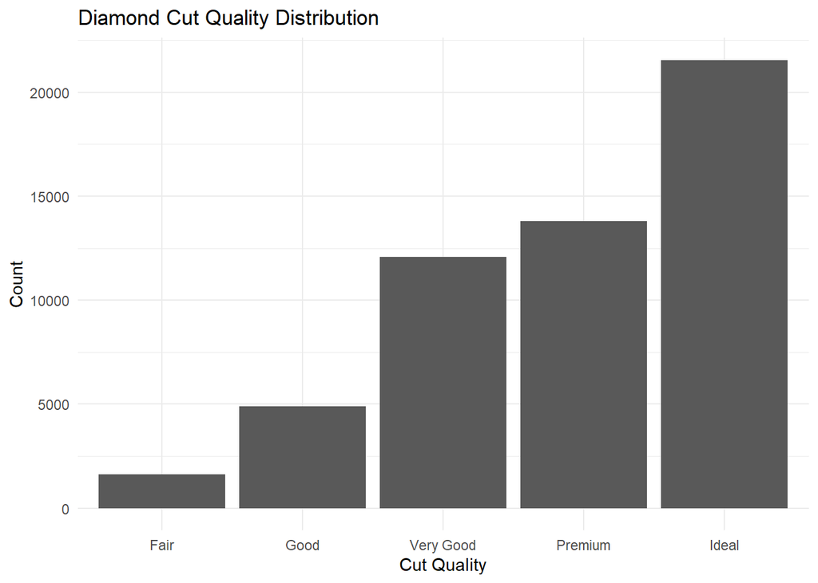

Bar chart of diamond cuts

#### Now let’s look at the diamond counts.

Diamond Count by Cut Quality

| cut | n |
| --- | --- |
| Ideal | 21551 |
| Premium | 13791 |
| Very Good | 12082 |
| Good | 4906 |
| Fair | 1610 |

#### Now, we will take a look at **continuous** variables.

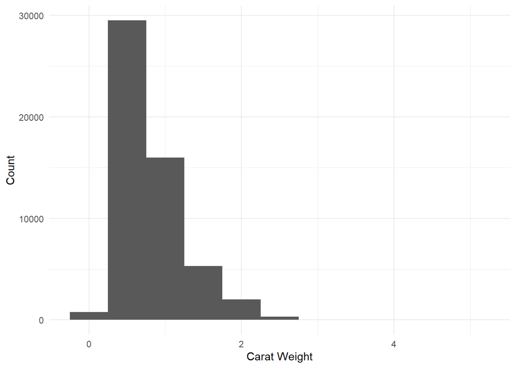

### Data Cleaning

Filters out diamonds ≥3 carats (potential outliers)

Higher resolution view with 0.1 carat bins.

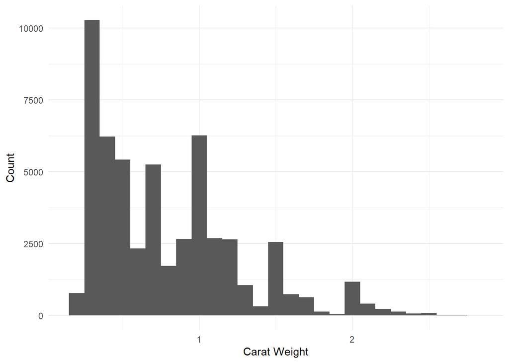

# Analysis

## Typical Values

> Which values are the most common and why?

> Which values are rare and why? Do they meet the required expectations?

> Are there any unusual patterns? What might explain them?

0.01 carat bins reveal subtle patterns.

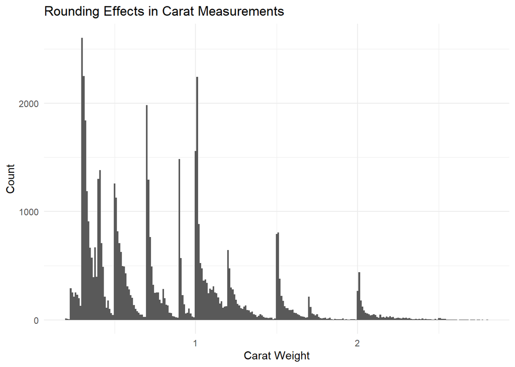

The graph shows some interesting curves that lead to even more questions that need to be answered, such as:

> Why are there more diamonds at whole carat values?

> Why are there more diamonds that are leaning more to the right of the common carat values?

#### Key observations:

> **Peaks at whole numbers**: Psychological pricing (1.0 carat preferred)

> **Right-skewed distribution**: Fewer large diamonds

> **Measurement rounding**: Clustering at fractional values

## Covariation

We will look at three different types of covariation.

### Categorical vs. Continuous

Boxplots show price distributions across cut categories.

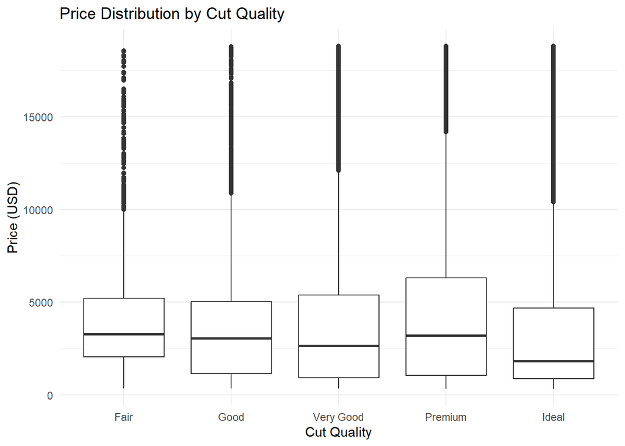

### Categorical vs. Categorical

Heatmap shows combinations of color and cut.

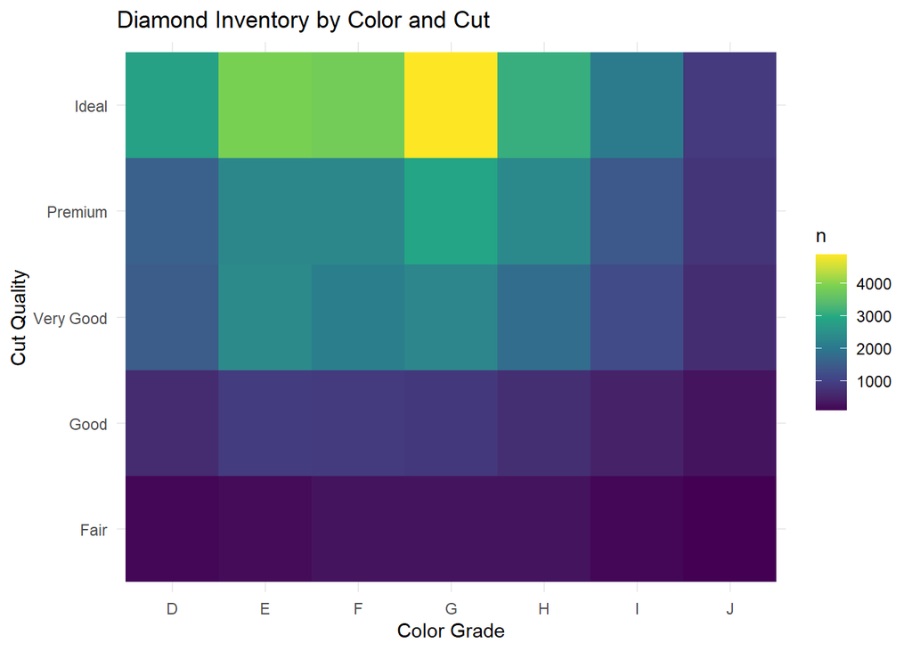

### Continuous vs. Continuous

Hexagonal binning handles overplotting.

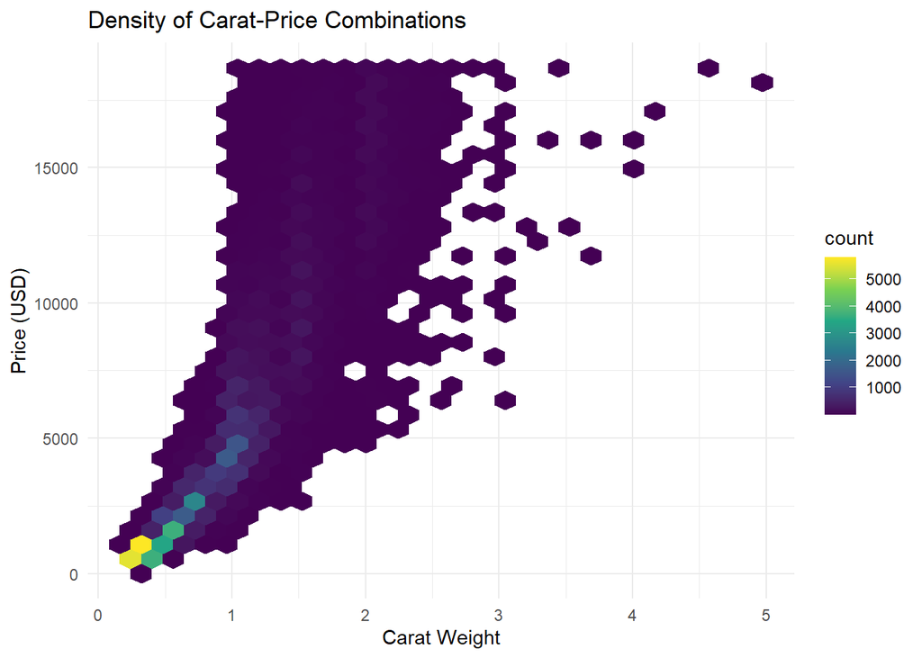

## Patterns and Models

Patterns in our data provide clues about the relationship between variables. If a systematic relationship exists between two variables, it will appear as a pattern in the data. Now ask the question whether this pattern is coincidental or random chance. How can we describe the relationship implied by the pattern? Is it positive or negative relationship? What we’ll be looking at is whether something is random chance or whether there’s some causal relationship between items.

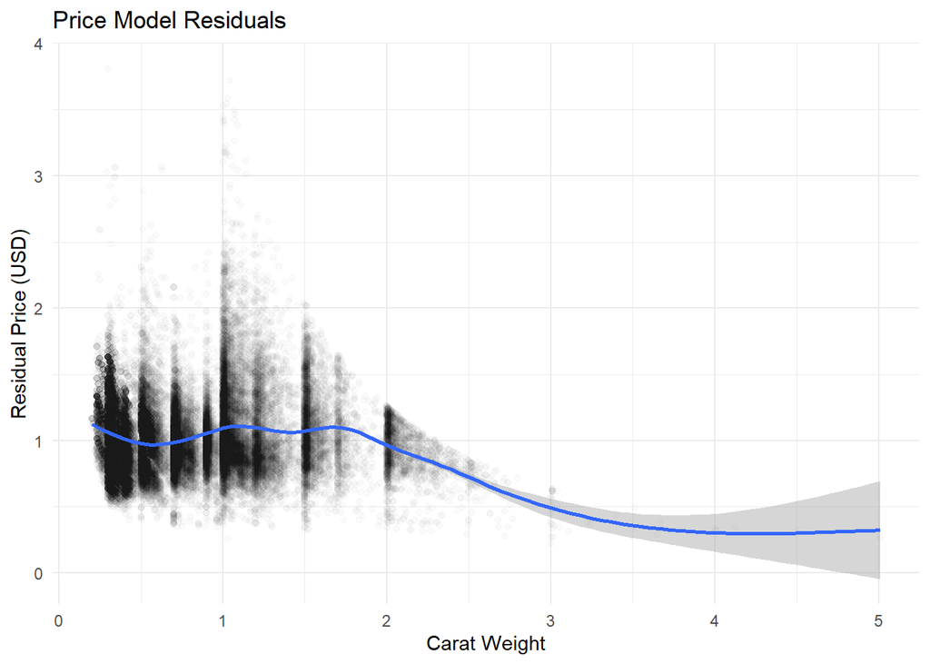

# Insights for Stakeholders

## Key Findings

### 1. Cut Quality Distribution:

> 40% of diamonds are “Ideal” cut.

> Only 3% are “Fair” cut.

### 2. Price Drivers:

> Carat weight explains 85% of price variation.

### 3. Inventory Insights:

> VS2/SI1 clarity dominates mid-range market.

## Recommended Visualizations

### 1. Executive Summary:

> Carat-price hexbin plot.

> Cut-quality distribution

### 2. Pricing Team:

> Model residuals plot

> Price by cut boxplots

### 3. Inventory Managers:

> Color-cut heatmap

> Carat distribution histograms

# Conclusion

This analysis revealed:

> **Non-linear pricing**: Prices increase exponentially with carat weight.

> **Cut-quality paradox**: Higher grades don’t always command premium prices.

> **Measurement artifacts**: Clear rounding in carat measurements.

## Recommendations

> Develop carat-specific pricing models.

> Investigate cut-quality perception in market.

> Standardize measurement protocols.